# RS-Data Analysis

## Data Processing

## Order

| InvoiceNo | StockCode | Description | Quantity | InvoiceDate | UnitPrice | CustomerID | Country |
| --- | --- | --- | --- | --- | --- | --- | --- |
| 536365 | 85123A | White Hanging Heart T-Light Holder | 6 | 2010-12-01 08:26:00 | 2.55 | 17850 | United Kingdom |
| 536365 | 71053 | White Metal Lantern | 6 | 2010-12-01 08:26:00 | 3.39 | 17850 | United Kingdom |
| 536365 | 84406B | Cream Cupid Hearts Coat Hanger | 8 | 2010-12-01 08:26:00 | 2.75 | 17850 | United Kingdom |

包含541909筆觀察值，8個變數

- InvoiceNo: 發票號碼
- StockCode: 貨物編號
- Description: 描述
- Quantity: 數量
- InvoiceDate: 發票日期
- UnitPrice: 單價
- CustomerID: 消費者ID
- Country: 城市

## Customer

| CustomerID | Gender | Age | Income | Zipcode | Customer Segment |
| --- | --- | --- | --- | --- | --- |
| 13089 | male | 53 | High | 8625 | Small Business |
| 15810 | female | 22 | Low | 87797 | Small Business |
| 15556 | female | 29 | High | 29257 | Corporate |

包含4372筆觀察值，6個變數

- CustomerID: 消費者ID
- Gender: 性別
- Age: 年齡
- Income: 收入
- Zipcode: 郵遞區號
- Customer Segment: 消費者分類

## Combined data

| CustomerID | InvoiceNo | StockCode | Description | Quantity | InvoiceDate | UnitPrice | Country | Gender | Age | Income | Zipcode | Customer Segment |
| --- | --- | --- | --- | --- | --- | --- | --- | --- | --- | --- | --- | --- |
| 12346 | C541433 | 23166 | Medium Ceramic Top Storage Jar | -74215 | 2011-01-18 10:17:00 | 1.04 | United Kingdom | male | 29 | Low | 5526 | Corporate |
| 12346 | 541431 | 23166 | Medium Ceramic Top Storage Jar | 74215 | 2011-01-18 10:01:00 | 1.04 | United Kingdom | male | 29 | Low | 5526 | Corporate |
| 12347 | 542237 | 84558A | 3D Dog Picture Playing Cards | 12 | 2011-01-26 14:30:00 | 2.95 | Iceland | female | 30 | High | 45822 | Small Business |

以CustomerID合併order和customer，合併完資料包含406829筆觀察值，13個變數

## Check

| Variable | Number of class |
| --- | --- |
| CustomerID | 4372 |
| InvoiceNo | 22190 |
| StockCode | 3684 |
| Description | 3885 |
| InvoiceDate | 20460 |
| Country | 37 |
| Gender | 2 |
| Income | 3 |
| Zipcode | 4282 |
| Customer Segment | 3 |

| Quantity | UnitPrice | Age |
| --- | --- | --- |
| Min. :-80995.00 | Min. : 0.00 | Min. :18.00 |
| 1st Qu.: 2.00 | 1st Qu.: 1.25 | 1st Qu.:27.00 |
| Median : 5.00 | Median : 1.95 | Median :38.00 |
| Mean : 12.06 | Mean : 3.46 | Mean :37.26 |
| 3rd Qu.: 12.00 | 3rd Qu.: 3.75 | 3rd Qu.:47.00 |
| Max. : 80995.00 | Max. :38970.00 | Max. :55.00 |

## 發現Quantity有負的

| CustomerID | InvoiceNo | StockCode | Description | Quantity | InvoiceDate |
| --- | --- | --- | --- | --- | --- |
| 12346 | 541431 | 23166 | Medium Ceramic Top Storage Jar | 74215 | 2011-01-18 10:01:00 |
| 12346 | C541433 | 23166 | Medium Ceramic Top Storage Jar | -74215 | 2011-01-18 10:17:00 |

| CustomerID | InvoiceNo | StockCode | Description | Quantity | InvoiceDate |
| --- | --- | --- | --- | --- | --- |
| 18268 | C561590 | 84968A | Set Of 16 Vintage Rose Cutlery | -2 | 2011-07-28 11:16:00 |
| 18268 | 561680 | 84968A | Set Of 16 Vintage Rose Cutlery | 2 | 2011-07-28 19:13:00 |

| CustomerID | InvoiceNo | StockCode | Description | Quantity | InvoiceDate |
| --- | --- | --- | --- | --- | --- |
| 18141 | C538717 | 22457 | Natural Slate Heart Chalkboard | -12 | 2010-12-14 11:09:00 |

- 退貨 (*´･д･)?

## 單價小於0.01

- 猜測單價為美元，所以最小幣值為美分(0.01美元)

|  | StockCode | Description | UnitPrice |
| --- | --- | --- | --- |
| 1 | 23234 | Biscuit Tin Vintage Christmas | 0 |
| 2 | 22619 | Set Of 6 Soldier Skittles | 0 |
| 3 | 22385 | Jumbo Bag Spaceboy Design | 0 |
| 4 | M | Manual | 0 |
| 5 | 23407 | Set Of 2 Trays Home Sweet Home | 0 |
| 6 | M | Manual | 0 |
| 43 | 47566 | Party Bunting | 0 |
| 44 | 21208 | Pastel Colour Honeycomb Fan | 0 |

- 贈品 ( •́ _ •̀)？

## StockCode的個數和Description的個數不一致

| CustomerID | InvoiceNo | StockCode | Description | Quantity | InvoiceDate |
| --- | --- | --- | --- | --- | --- |
| 15749 | 540815 | 21108 | Fairy Cake Flannel Assorted Colour | 3114 | 2011-01-11 12:55:00 |
| 15749 | C550456 | 21108 | Fairy Cake Flannel Assorted Colour | -3114 | 2011-04-18 13:08:00 |
| 15749 | 550461 | 21108 | Fairy Cake Flannel Assorted Colour | 3114 | 2011-04-18 13:20:00 |
| 15749 | 540815 | 21175 | Gin + Tonic Diet Metal Sign | 2000 | 2011-01-11 12:55:00 |
| 15749 | C550456 | 21175 | Gin + Tonic Diet Metal Sign | -2000 | 2011-04-18 13:08:00 |
| 15749 | 550461 | 21175 | Gin + Tonic Diet Metal Sign | 2000 | 2011-04-18 13:20:00 |
| 15749 | 540818 | 47556B | Tea Time Tea Towels | 1300 | 2011-01-11 12:57:00 |
| 15749 | 550461 | 47556B | Tea Time Tea Towels | 1300 | 2011-04-18 13:20:00 |
| 15749 | C550456 | 47566B | Tea Time Party Bunting | -1300 | 2011-04-18 13:08:00 |
| 15749 | 540818 | 48185 | Doormat Fairy Cake | 670 | 2011-01-11 12:57:00 |
| 15749 | C550456 | 48185 | Doormat Fairy Cake | -670 | 2011-04-18 13:08:00 |
| 15749 | 550461 | 48185 | Doormat Fairy Cake | 670 | 2011-04-18 13:20:00 |
| 15749 | 540815 | 85123A | White Hanging Heart T-Light Holder | 1930 | 2011-01-11 12:55:00 |
| 15749 | C550456 | 85123A | White Hanging Heart T-Light Holder | -1930 | 2011-04-18 13:08:00 |
| 15749 | 550461 | 85123A | White Hanging Heart T-Light Holder | 1930 | 2011-04-18 13:20:00 |

## 移除Quantity有負的”消費者”和單價小於0.01的”交易”

| Variable | Number of class (new) | Number of class (old) |
| --- | --- | --- |
| CustomerID | 2782 | 4372 |
| InvoiceNo | 6955 | 22190 |
| StockCode | 3506 | 3684 |
| Description | 3638 | 3885 |
| Country | 32 | 37 |
| Gender | 2 | 2 |
| Income | 3 | 3 |
| Zipcode | 2746 | 4282 |
| Customer Segment | 3 | 3 |

- 性別: female, male
- 收入: High, Low, Medium
- 消費者分類: Small Business, Middle class, Corporate
- 發票日期: 2010-12-01 09:00:00, 2011-12-09 12:50:00

|  | Quantity | UnitPrice | Age |
| --- | --- | --- | --- |
|  | Min. : 1.000 | Min. : 0.040 | Min. :18.00 |
|  | 1st Qu.: 2.000 | 1st Qu.: 1.250 | 1st Qu.:28.00 |
|  | Median : 4.000 | Median : 1.690 | Median :37.00 |
|  | Mean : 9.379 | Mean : 2.843 | Mean :36.76 |
|  | 3rd Qu.: 12.000 | 3rd Qu.: 3.450 | 3rd Qu.:46.00 |
|  | Max. :4300.000 | Max. :2033.100 | Max. :55.00 |

## Methods

- Conjoint Analysis
- Association Rule
- Collaborative filtering

## choose method

| CustomerID | InvoiceNo | StockCode | Description | Quantity | InvoiceDate | UnitPrice | Country | Gender | Age | Income | Zipcode | Customer Segment |
| --- | --- | --- | --- | --- | --- | --- | --- | --- | --- | --- | --- | --- |
| 12347 | 542237 | 84558A | 3D Dog Picture Playing Cards | 12 | 2011-01-26 14:30:00 | 2.95 | Iceland | female | 30 | High | 45822 | Small Business |

- Conjoint Analysis: 需要ranking，所以沒辦法做
- Association Rule: 找出物件的組合 (以商品編號為主)
- Collaborative filtering: 根據使用者和物品的相似性進行推薦，以有沒有買來推薦 (0/1)

## Association Rule

## Itemfrequency Plot (以消費者ID)

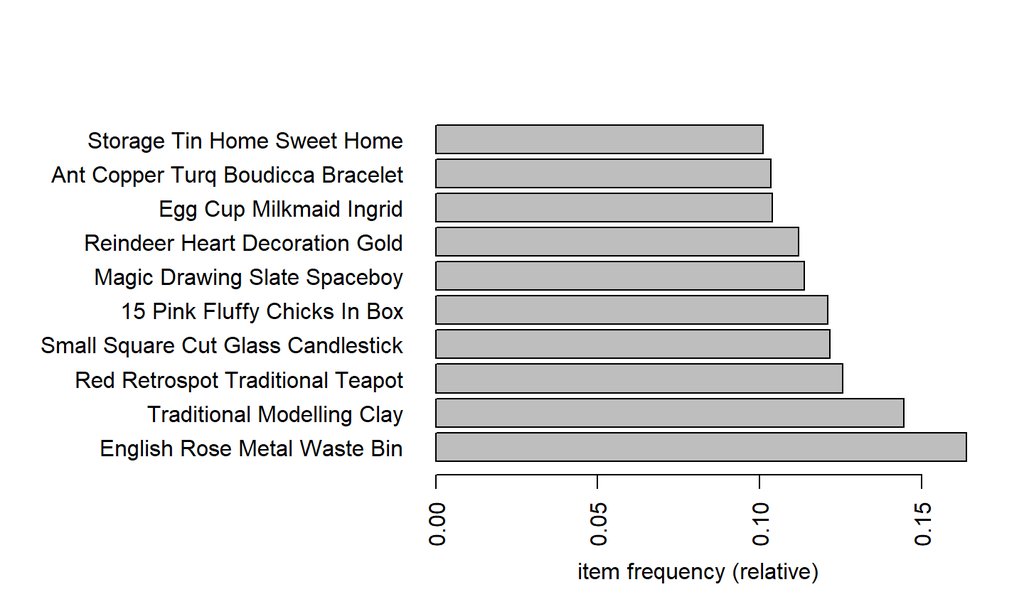

## Itemfrequency Plot (以發票號碼)

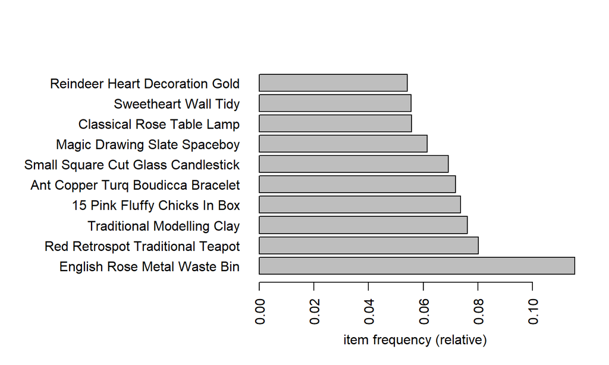

- 多了收納袋和檯燈，少了蛋杯和儲藏罐

- 以消費者ID

| LHS | RHS | support | confidence | coverage | lift |
| --- | --- | --- | --- | --- | --- |
| {22698} | {22697} | 0.04 | 0.91 | 0.05 | 14.95 |
| {22697} | {22698} | 0.04 | 0.70 | 0.06 | 14.95 |
| {21136} | {84879} | 0.04 | 0.78 | 0.05 | 6.42 |
| {22697} | {22699} | 0.05 | 0.76 | 0.06 | 12.32 |
| {22699} | {22697} | 0.05 | 0.75 | 0.06 | 12.32 |
| {22617} | {22138} | 0.04 | 0.83 | 0.05 | 7.38 |
| {22804} | {85123A} | 0.04 | 0.89 | 0.05 | 5.42 |
| {22578} | {22577} | 0.04 | 0.75 | 0.06 | 11.97 |
| {22577} | {22578} | 0.04 | 0.72 | 0.06 | 11.97 |
| {23300} | {23301} | 0.04 | 0.72 | 0.06 | 10.48 |
| {21733} | {85123A} | 0.06 | 0.79 | 0.07 | 4.83 |

- 以發票號碼

| LHS | RHS | support | confidence | coverage | lift |
| --- | --- | --- | --- | --- | --- |
| {22697} | {22699} | 0.02 | 0.73 | 0.03 | 23.53 |
| {22699} | {22697} | 0.02 | 0.70 | 0.03 | 23.53 |
| {22804} | {85123A} | 0.02 | 0.79 | 0.03 | 6.85 |
| {22578} | {22577} | 0.02 | 0.75 | 0.03 | 25.20 |
| {22726} | {22727} | 0.02 | 0.71 | 0.03 | 16.78 |
| {23300} | {23301} | 0.03 | 0.75 | 0.03 | 17.64 |
| {21733} | {85123A} | 0.03 | 0.70 | 0.04 | 6.07 |

## check

| code | discription |
| --- | --- |
| 22698 | Pink Regency Teacup And Saucer |
| 22697 | Green Regency Teacup And Saucer |
| 22699 | Roses Regency Teacup And Saucer |
| 22578 | Wooden Star Christmas Scandinavian |
| 22577 | Wooden Heart Christmas Scandinavian |
| 21733 | Red Hanging Heart T-Light Holder |
| 85123A | White Hanging Heart T-Light Holder |
| 22726 | Alarm Clock Bakelike Green |
| 22727 | Alarm Clock Bakelike Red |

## Collaborative filtering

## Binarization

- 以Quantity為評分，大於等於1為1，其餘為0
- 保留 (中位數)
  - 買過超過27件物品的使用者
  - 被超過19個使用者購買過的物品

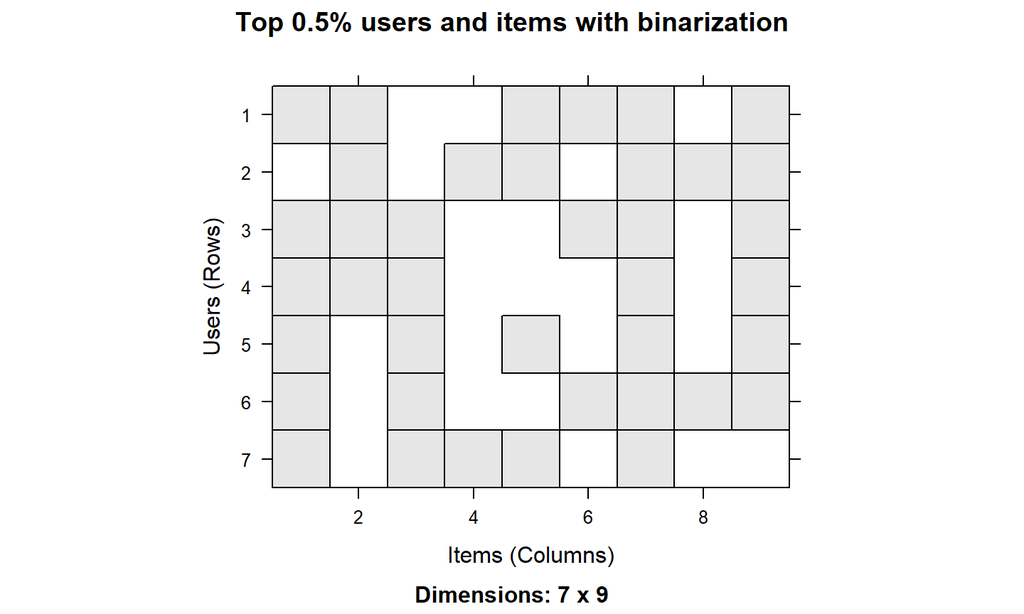

## IBCF (method = “Jaccard”)

推薦給第一個使用者的項目

| User 1 |
| --- |
| Childrens Cutlery Polkadot Green |
| Charlotte Bag Pink Polkadot |
| Red Retrospot Charlotte Bag |
| Charlotte Bag Suki Design |
| Charlotte Bag Dolly Girl Design |
| Strawberry Charlotte Bag |

推薦最多的前4個項目

| Item | Recommend times |
| --- | --- |
| Lunch Bag Red Retrospot | 124 |
| Lunch Bag Pink Polkadot | 114 |
| Lunch Bag Spaceboy Design | 111 |
| Lunch Bag Apple Design | 110 |

## Popular

推薦給第一個使用者的項目

| User 1 |
| --- |
| White Hanging Heart T-Light Holder |
| Rex Cash+Carry Jumbo Shopper |
| Paper Chain Kit 50’S Christmas |
| Assorted Colour Bird Ornament |
| Party Bunting |
| Baking Set 9 Piece Retrospot |

推薦最多的前4個項目

| Item | Recommend times |
| --- | --- |
| Regency Cakestand 3 Tier | 1130 |
| Party Bunting | 1117 |
| Assorted Colour Bird Ornament | 1104 |
| Paper Chain Kit 50’S Christmas | 1087 |